# Return levels

Decide the city and variable we want to carry out the analysis on.

```r
city <- 'NEW DELHI (SAFDARJUNG (A))'
var.name <- 'Tmax'
var_names <- list(Prec='Precipitation', Tmin='Miniumum Temperature',
                  Tmax='Maximum Temperature')
```

```r
library(extRemes)
library(dplyr)
library(tidyr)
```

## Extract time series

Read in the *wrangled* data-set prepared from originally provided IMD station data

```r
abs_dir <- '/home/abhi/Documents/mygit/EVS'
rel_dir <- 'pickles'
fname <- 'df_ally_full.rds'
f <- paste(c(abs_dir, rel_dir, fname), collapse = '/')
df <- readRDS(f)
df <- df %>%
  gather("variable", "value", Tmax, Tmin, Prec)

df
```

| ID | obs | tobs | month | day | year | City | Date | variable | value |
| --- | --- | --- | --- | --- | --- | --- | --- | --- | --- |
| 10202 | 1 | 1 | 1 | 1 | 1969 | JODHPUR | 1969-01-01 | Tmax | NA |
| 10202 | 2 | 2 | 1 | 2 | 1969 | JODHPUR | 1969-01-02 | Tmax | NA |
| 10202 | 3 | 3 | 1 | 3 | 1969 | JODHPUR | 1969-01-03 | Tmax | NA |
| 10202 | 4 | 4 | 1 | 4 | 1969 | JODHPUR | 1969-01-04 | Tmax | NA |
| 10202 | 5 | 5 | 1 | 5 | 1969 | JODHPUR | 1969-01-05 | Tmax | NA |
| 10202 | 6 | 6 | 1 | 6 | 1969 | JODHPUR | 1969-01-06 | Tmax | NA |
| 10202 | 7 | 7 | 1 | 7 | 1969 | JODHPUR | 1969-01-07 | Tmax | NA |
| 10202 | 8 | 8 | 1 | 8 | 1969 | JODHPUR | 1969-01-08 | Tmax | NA |
| 10202 | 9 | 9 | 1 | 9 | 1969 | JODHPUR | 1969-01-09 | Tmax | NA |
| 10202 | 10 | 10 | 1 | 10 | 1969 | JODHPUR | 1969-01-10 | Tmax | NA |

[output cut: 990 more lines]

Define a custom max function to handle vectors with both all NA values or some NA values

```r
# Is there a better and direct way in dplyr than defining a custom function?
my.max <- function(..., na.rm=T){
  if(!is.finite(suppressWarnings(max(..., na.rm = na.rm)))){
    return(NA) # TODO: return the right NA type?
  }else{
    return(max(..., na.rm = na.rm))
  }
}
```

Extract out relevant df’s and vectors for further analysis

```r
# Annual maxima
df_ymax <-
  df %>%
  group_by(ID, City, year, variable) %>%
  summarise(value=my.max(value)) %>%
  arrange(variable) %>%
  ungroup()

# Annual maxima for the selected city and variable
df.p.ymax <-
  df_ymax %>%
  filter(City == city, variable == var.name) %>%
  mutate(ID=as.character(ID),
         City=as.character(City))

# Extract vectors
rf.p.ymax <- df.p.ymax$value
years <- df.p.ymax$year

# All time series for the selected city and variable
df.p <- df %>%
  filter(City == city, variable == var.name) %>%
  ungroup() %>%
  mutate(ID=as.character(ID),
         City=as.character(City))

rf.p <- df.p$value # All time series
rf.p2 <- rf.p[!is.na(rf.p)] # Time series with NA removed

rf.p.df <- df.p # For naming consistency in the further notebook analyses
                # TODO: Refactor this to a more general name.

# Range of years in the data
# TODO: Even though this isn't used anywhere for calculation
#       Still should be according to the range of 1st and last non-NA point
years_range <- paste0(min(years), '-', max(years))

df_data <- rf.p.df %>% drop_na() # Non-NA df
```

## 1. Block Maxima approach

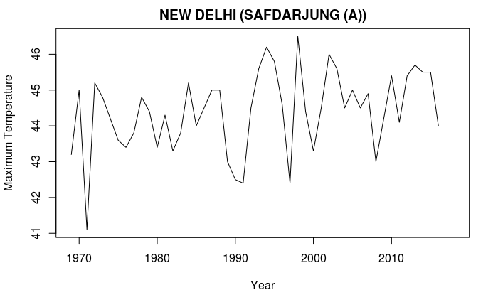

### Fit the block maxima to GEV distribution.

The GEV df is given by,  
$G(x) = exp[-\{1 + \xi(\dfrac{x - u}{\sigma})\}^{-1/\xi}]$,  
which in the limit $\xi \longrightarrow 0$ results in the Gumbel distribution given by,  
$G(x) = exp[-exp\{-(\dfrac{x-u}{\sigma})\}]$

$Type \hspace{0.1cm} I$ **Gumbel**: $\xi = 0$  
$Type \hspace{0.1cm} II$ **Fretchet**: $\xi > 0$, Heavy tailed  
$Type \hspace{0.1cm} III$ **Upper bounded Weibull**: $\xi < 0$, (reverse or reflected Weibull)

```r
fit <- fevd(rf.p.ymax, units = "mm/day")
fit
```

```
fevd(x = rf.p.ymax, units = "mm/day")

[1] "Estimation Method used: MLE"


 Negative Log-Likelihood Value:  71.33853


 Estimated parameters:
  location      scale      shape
44.0958334  1.1853017 -0.4493876

 Standard Error Estimates:
  location      scale      shape
0.18480328 0.13459116 0.08091807

 Estimated parameter covariance matrix.
             location        scale        shape
location  0.034152254 -0.005994748 -0.005450444
scale    -0.005994748  0.018114781 -0.007101661
shape    -0.005450444 -0.007101661  0.006547734

 AIC = 148.6771

 BIC = 154.2907
```

### Plot the fit.

1. qqplot
2. qqplot2 with regression line (with 95% confidence interval), 1:1 line.
3. Compare empirical density v/s GEV probability distribution
4. Return level plot for different return periods.

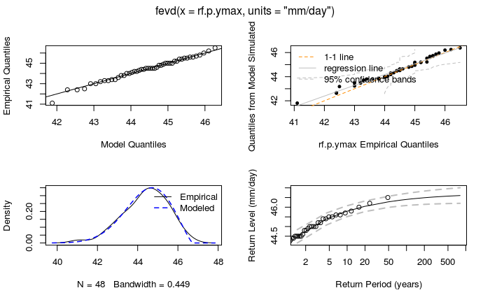

### Return level estimates

Estimate return levels for different return periods. The confidence intervals are based on normal approximation of the return level estimator.

```r
return.level(fit, return.period = c(2, 5, 10, 20, 50, 100), do.ci=TRUE)
```

```
fevd(x = rf.p.ymax, units = "mm/day")

[1] "Normal Approx."

                      95% lower CI Estimate 95% upper CI
2-year return level       44.15083 44.49637     44.84191
5-year return level       45.08087 45.38921     45.69755
10-year return level      45.49074 45.77400     46.05727
20-year return level      45.76647 46.03916     46.31185
50-year return level      45.98971 46.27668     46.56364
100-year return level     46.08706 46.39968     46.71231
```

Calculating return levels from a GEV distribution.

We need to find the probability of exceeding certain precipitation amount *x* which exceeds every *m* years. This implies, that the probability of precipitation exceeding amount *x* is $1/m$.

$P(X > x) = 1 - P(X \le x)$, ($X:$ Annual maximum precipitation)  
For an *m* year return period, we have $P(X > x) = 1/m$,  
Hence we have, $1/m = 1 - P(X \le x)$  
$\implies P(X \le x) = 1 - 1/m$,  
We have estimated the *CDF* of $X$, by fitting the block maxima to a *GEV* distribution.  
So, we have $X \sim GEV(x \hspace{0.1cm} |\hspace{0.1cm} \mu, \sigma, \xi)$  
So, from the *CDF* of X, we need to find $1 - 1/m$ quantile.

```r
print(rlevs)
```

```
  2-year level   5-year level  10-year level  20-year level  50-year level 100-year level
      44.49637       45.38921       45.77400       46.03916       46.27668       46.39968
```

```r
rlevs <- as.vector(return.level(fit, return.period = rperiods))
names(rlevs) <- paste0(rperiods, "-year level")
print(rlevs)
```

[output not shown]

### Parameter estimates

The confidence intervals are based on normal approximation of the parameter estimators.

```r
ci(fit, type="parameter")
```

[output not shown]

#### Demonstrate confidence interval for the shape parameter using normal approximation.

The answer comes out to be same as calcuated by the package function ci.

```r
xi.mean <- distill(fit)["shape"]
xi.sd <- sqrt(distill(fit)["shape.shape"])
# 95% confidence interval
qnorm(c(0.025, 0.975), xi.mean, xi.sd)
```

```
[1] -0.003922313  0.367880127
```

#### Profile likelihood

1. Plot Log likelihood plots of the parameters and its gradient for each parameter.  
   **Note**: For each paramter this holds other parameters at their MLE.  
   This is important for deriving confidence intervals of the parameter estimates in the case when the log likelihood is not symmetrical about MLE.

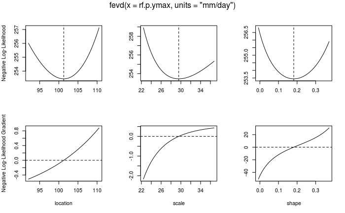

```r
plot(fit, "trace")
```

2. Obtain ci based on profile likelihood method by specifying the range in which to look for the confidence interval

First let’s print out the normal approx. confidence interval for $\xi$ i.e. the shape parameter.

```r
ci(fit, type="parameter", which.par = 3, method="normal")
```

```
fevd(x = rf.p.ymax, units = "mm/day")

[1] "Normal Approx."

[1] "shape: 0.182"

[1] "95% Confidence Interval: (-0.0039, 0.3679)"
```

Now let’s calculate it using profile likelihood method.  
**NOTE**: Different ranges in which to look will produce slightly different confidence intervals. I don’t know how to specify a good range to look for the confidence interval. This is usually determined by trial and error by looking at the profile likelihood plot.

```r
ci(fit, type="parameter", which.par = 3, xrange = c(-0.2, 0.6), method="proflik")
```

```
fevd(x = rf.p.ymax, units = "mm/day")

[1] "Profile Likelihood"

[1] "shape: 0.182"

[1] "95% Confidence Interval: (0.0232, 0.3956)"
```

Now let’s calculate the confidence intervals for return level estimates 1. Normal approximation

```r
return.level(fit, return.period = 50, do.ci = T, method="normal")
```

```
fevd(x = rf.p.ymax, units = "mm/day")

[1] "Normal Approx."

[1] "50-year return level: 269.322"

[1] "95% Confidence Interval: (187.4913, 351.1524)"
```

2. Profile likelihood method  
   The profile likelihood plot should have the confidence interval within the range used and not merely be endpoints of the range specified.

```
 Preparing to calculate  95 % CI for  50-year return level

 Model is   fixed

 Using Profile Likelihood Method.

 Calculating profile likelihood.  This may take a few moments.

 Profile likelihood has been calculated.  Now, trying to find where it crosses the critical value =  -255.3634
fevd(x = rf.p.ymax, units = "mm/day")

[1] "Profile Likelihood"

[1] "50-year return level: 269.322"

[1] "95% Confidence Interval: (220, 413.3668)"
```

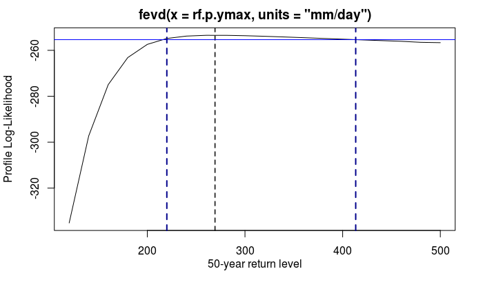

```r
ci(fit, which.par = 3, return.period = 50, xrange = c(120, 500),
   method = 'proflik', verbose = T)
```

### Return levels for particular amount of rainfall

```r
# Precipitation amounts for which to find return levels
precip.v <- seq(100, 200, 20)

# Probability of exceeding
prob.exceedance <- pextRemes(fit, q = precip.v, lower.tail = FALSE)
prob.exceedance
```

```
[1] 0.64816940 0.42267157 0.26583444 0.16771573 0.10782481 0.07100001
```

```r
# Return period (in years)
fit.rlevels <- 1/prob.exceedance
names(fit.rlevels) <- paste(precip.v, "mm")
fit.rlevels
```

```
   100 mm    120 mm    140 mm    160 mm    180 mm    200 mm
 1.542807  2.365903  3.761740  5.962470  9.274304 14.084505
```

### Likelihood ratio test

Note that the 95 % confidence interval gives a range whose lower bound goes to negative. This means that $\xi$ could be 0. We know that when $\xi$ = 0, we have a gumbel distribution. To test this we perform a likelihood ratio test.  
$H_o$ : The distribution is Gumbel.  
$H_a$ : The distribution is Fretchet  
Note: The model with the fewer parameters is always (mostly) the Null Hypothesis. Because a model with 3 parameters (i.e. Fretchet ($\mu, \sigma, \xi$)) is *more complex* than a model with 2 parameters (i.e. Gumbel ($\mu, \sigma$)), and in statistics we penalize complexity, hence $H_o$ is Gumbel and $H_a$ is Fretchet.

1. Fit to a gumbel distribution

```r
fit.gumbel <- fevd(rf.p.ymax, type = "Gumbel", units = "mm/day")
fit.gumbel
```

```
fevd(x = rf.p.ymax, type = "Gumbel", units = "mm/day")

[1] "Estimation Method used: MLE"


 Negative Log-Likelihood Value:  256.0266


 Estimated parameters:
 location     scale
104.39313  32.27076

 Standard Error Estimates:
location    scale
4.751290 3.737341

 Estimated parameter covariance matrix.
          location     scale
location 22.574758  4.939396
scale     4.939396 13.967720

 AIC = 516.0532

 BIC = 519.8773
```

```r
lr.test(fit, fit.gumbel)
```

```
    Likelihood-ratio Test

data:  rf.p.ymaxrf.p.ymax
Likelihood-ratio = 5.1679, chi-square critical value = 3.8415, alpha = 0.0500, Degrees of Freedom
= 1.0000, p-value = 0.02301
alternative hypothesis: greater
```

### Fit using L-moments approach (estimation of parameters)

```r
fitLM <- fevd(rf.p.ymax, method = "Lmoments")
fitLM
```

```
fevd(x = rf.p.ymax, method = "Lmoments")
[1] "GEV  Fitted to  rf.p.ymax  using L-moments estimation."
  location      scale      shape
99.5713873 26.5916354  0.2855904
```

```r
ci(fitLM)
```

```
fevd(x = rf.p.ymax, method = "Lmoments")

[1] "Parametric Bootstrap"
502  iterations

[1] "100-year level: 352.846"

[1] "95% Confidence Interval: (219.3117, 610.5132)"
```

```r
ci(fitLM, type = "parameter")
```

```
fevd(x = rf.p.ymax, method = "Lmoments")

[1] "Parametric Bootstrap"
502  iterations

                 2.5%   Estimate       97.5%
location 91.636897156 99.5713873 109.1005397
scale    19.188444511 26.5916354  36.1210773
shape    -0.004963409  0.2855904   0.5339153
```

## 2. Peak over threshold approach

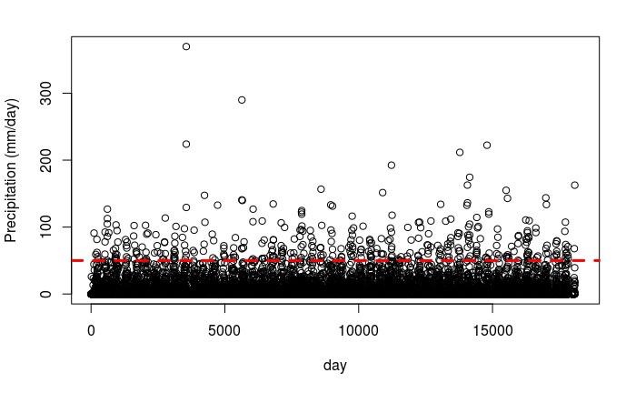

```r
# set any arbitrary threshold to visualize excesses
set.thresh <- 50
plot(rf.p, xlab = "day", ylab = "Precipitation (mm/day)"); abline(set.thresh, 0, col="red", lwd=3, lty=2)
```

### Threshrange plot

Repeatedly fits the GP df to the data for a sequence of threshold choices. Confidence interval bands are shown as bars.

**Bias** : Too low a threshold, implies the asymptotic assumption becomes invalid however the amount of data samples is high thereby reducing the uncertainty (variance) in the estimate (short bars) .

**Variance** : Too high a threshold, implies the asymptotic assumption becomes valid however the too less data samples mean a high uncertainty in the estimate (long bars).

**Reparameterized scale** : $\sigma^{*} = \sigma (u) - \xi u$, adjusted so that it is not a function of the threshold.

The mean of the GP df is given by $E[X - u | X > u] = \sigma (u)/ (1- \xi) = (\sigma (u_{o}) + \xi u)/(1- \xi)$, which is a linear function of the threshold.

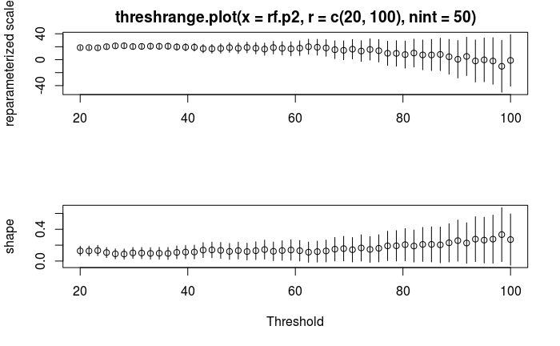

```r
threshrange.plot(rf.p2, r = c(20, 100), nint = 50)
```

### Mean excess

The mean excess above a threshold is defined as  
$e_X(u) = \sum_{i=1}^{n_u} (x_i - u)$  
where $x_i, ...., x_{n_{u}}$ are observations that exceed the threshold $u$. If the exceedances of a threshold u0 are generalized Pareto, the empirical mean residual life plot should be approximately linear for u > u0.

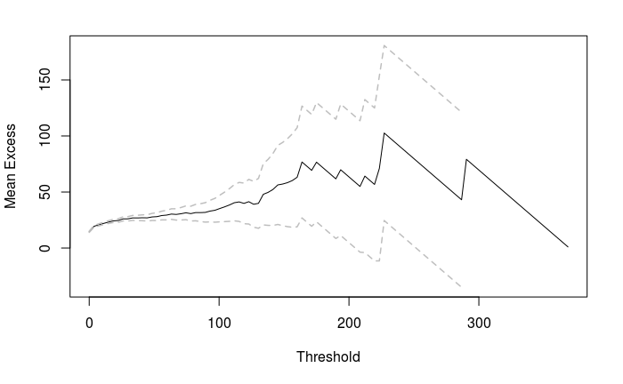

```r
mrlplot(rf.p2)
```

Does **50** (mm) look like an appropriate threshold?  
Let’s check the number of data points above 50

```r
set.thresh <- 50
print(paste("The number of data points above", set.thresh, "mm is",
            length(rf.p2[rf.p2 > set.thresh])))
```

```
[1] "The number of data points above 50 mm is 388"
```

```r
print(paste(set.thresh, "mm  corresponds to",
            round(ecdf(rf.p2)(set.thresh)*100, 2),
            "percentile of the data"))
```

```
[1] "50 mm  corresponds to 97.79 percentile of the data"
```

```r
# Print the df
rf.p.df
```

| ID | obs | tobs | month | day | year | City | Date | variable | value |
| --- | --- | --- | --- | --- | --- | --- | --- | --- | --- |
| 42807 | 1 | 1 | 1 | 1 | 1969 | KOLKATA (ALIPORE) | 1969-01-01 | Prec | 0.0 |
| 42807 | 2 | 2 | 1 | 2 | 1969 | KOLKATA (ALIPORE) | 1969-01-02 | Prec | 0.0 |
| 42807 | 3 | 3 | 1 | 3 | 1969 | KOLKATA (ALIPORE) | 1969-01-03 | Prec | 0.0 |
| 42807 | 4 | 4 | 1 | 4 | 1969 | KOLKATA (ALIPORE) | 1969-01-04 | Prec | 0.0 |
| 42807 | 5 | 5 | 1 | 5 | 1969 | KOLKATA (ALIPORE) | 1969-01-05 | Prec | 0.0 |
| 42807 | 6 | 6 | 1 | 6 | 1969 | KOLKATA (ALIPORE) | 1969-01-06 | Prec | 0.0 |
| 42807 | 7 | 7 | 1 | 7 | 1969 | KOLKATA (ALIPORE) | 1969-01-07 | Prec | 0.0 |
| 42807 | 8 | 8 | 1 | 8 | 1969 | KOLKATA (ALIPORE) | 1969-01-08 | Prec | 0.0 |
| 42807 | 9 | 9 | 1 | 9 | 1969 | KOLKATA (ALIPORE) | 1969-01-09 | Prec | 0.0 |
| 42807 | 10 | 10 | 1 | 10 | 1969 | KOLKATA (ALIPORE) | 1969-01-10 | Prec | 0.0 |

[output cut: 990 more lines]

### Fit the excesses 1

```r
# By default the time units for the event are 365.25/year
# Since we have daily data, we don't need to specify them explicitly.
fit.pot1 <- fevd(rf.p2, threshold = 50, type = "GP", units = "mm")
fit.pot1
```

```
fevd(x = rf.p2, threshold = 50, type = "GP", units = "mm")

[1] "Estimation Method used: MLE"


 Negative Log-Likelihood Value:  1675.823


 Estimated parameters:
     scale      shape
24.2537779  0.1305593

 Standard Error Estimates:
     scale      shape
1.80489972 0.05481297

 Estimated parameter covariance matrix.
            scale        shape
scale  3.25766300 -0.063643862
shape -0.06364386  0.003004462

 AIC = 3355.646

 BIC = 3363.568
```

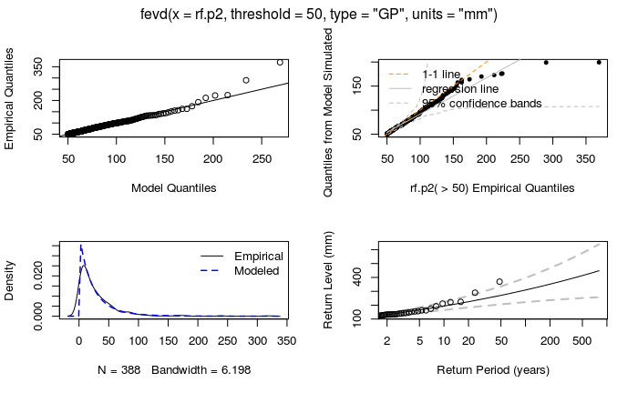

```r
plot(fit.pot1)
```

We can calculate the return levels for the POT fit.

```r
return.level(fit.pot1, rperiods)
```

```
fevd(x = rf.p2, threshold = 50, type = "GP", units = "mm")
get(paste("return.level.fevd.", newcl, sep = ""))(x = x, return.period = return.period)
[1] "GP model fitted to rf.p2 (mm)"
Data are assumed to be  stationary
[1] "Return Levels for period units in years"
  2-year level   5-year level  10-year level  20-year level  50-year level 100-year level
      131.3003       165.2394       193.7503       224.9616       270.8032       309.3129
```

Calculating return levels for a *GPD* fit is a little bit different. We know the excess (peaks) above a threshold $u$, follow a *GPD* distribution.  
**Final Goal** : We need to find the probability of exceeding a certain precipitation amount *x* which exceeds every *m* years.  
$prob(X \le x \hspace{0.1cm}|\hspace{0.1cm} X > u) = GPD(x-u\hspace{0.1cm}| \hspace{0.1cm} \sigma, \xi)$  
$prob(X > x \hspace{0.1cm}|\hspace{0.1cm} X > u) = 1 - GPD(x-u\hspace{0.1cm}| \hspace{0.1cm} \sigma, \xi)$

We know, $P(X > x\hspace{0.1cm}| \hspace{0.1cm} X > u) = \dfrac{P(X> x,X> u)}{P(X > u)}$  
But, $P(X >x, X>u) = P(X>x)$, $\implies P(X > x\hspace{0.1cm}| \hspace{0.1cm} X > u) = \dfrac{P(X> x)}{P(X > u)}$  
Simplyfying we get, $P(X > x\hspace{0.1cm}) = P(X > u)\cdot P(X> x \hspace{0.1cm} | \hspace{0.1cm}X> u)$  
$\implies P(X > x) = P(X > u)\cdot (1 - GPD(x-u\hspace{0.1cm}| \hspace{0.1cm} \sigma, \xi))$  
We can find $P(X >u)$ empirically (withput fitting the data) by calculating the number of data points above $u$.  
Since, in our case, the frequency of data points is daily, we have the probability of exceeding the precipitation amount *x* on any day of the year, $P(X > x) = P(X > u)\cdot (1 - GPD(x-u\hspace{0.1cm}| \hspace{0.1cm} \sigma, \xi))$  
For an *m*-year return period, $P(X > x) = \dfrac{1}{m} \cdot \dfrac{1}{365.25}$,  
$\implies \dfrac{1}{m} \cdot \dfrac{1}{365.25} = P(X > u)\cdot (1 - GPD(x-u\hspace{0.1cm}| \hspace{0.1cm} \sigma, \xi)$  
$\implies GPD(x-u\hspace{0.1cm}| \hspace{0.1cm} \sigma, \xi) = 1-(\dfrac{1}{m} \cdot \dfrac{1}{365} \cdot \dfrac {1}{P(X > u)})$

i.e. we need to find the $1-(\dfrac{1}{m} \cdot \dfrac{1}{365.25} \cdot \dfrac {1}{P(X > u)})$ quantile from the *GPD* CDF.

```r
#Empirical probability P(X>u) from data
u <- 50
p.gtu <- length(rf.p2[rf.p2 > u])/ length(rf.p2)

# Make Fit object easier to manage
fit.distilled <- distill(fit.pot1)

for (param in c("scale", "shape")){
  assign(param, fit.distilled[param])
}

# get [1 - (1/m * 1/365 * P(X > u))] quantile from the cdf
## Calculate 2, 5, 10, 20, 50, 100 year return levels
rperiods <- c(2, 5, 10, 20, 50, 100)
rlevs <- c()
for (m in rperiods){

   rlevs<- c(rlevs, qevd(1 - ((1/m)*(1/365.25)*(1/p.gtu)), scale = scale, shape = shape, threshold = 50, type = "GP"))
}
names(rlevs) <- paste0(rperiods, "-year level")
print(rlevs)
```

```
  2-year level   5-year level  10-year level  20-year level  50-year level 100-year level
      131.3003       165.2394       193.7503       224.9616       270.8032       309.3129
```

Which is the same as calculated by the package

```r
rlevs <- as.vector(return.level(fit.pot1, return.period = rperiods))
names(rlevs) <- paste0(rperiods, "-year level")
print(rlevs)
```

```
  2-year level   5-year level  10-year level  20-year level  50-year level 100-year level
      131.3003       165.2394       193.7503       224.9616       270.8032       309.3129
```

### Fit the excesses 2

Seasonality => Non-stationarity of the data.  
Taking into account seasonality while estimating the scale parameter. A common way to model seasonality is to assume sines and cosines with period = 1 year. So for every *day of the year* we have a different scale parameter.

$\sigma (t) = exp(\phi_{o} + \phi_{1}cos(2\pi\cdot t/365.25) + \phi_{2}sin(2\pi\cdot t/365.25)),\hspace{0.2cm} t = 1,2,....,365$

```r
fit.pot2 <- fevd(value, data=as.data.frame(df_data), threshold = 50,
                 scale.fun = ~ cos(2 * pi * tobs / 365.25) + sin(2 * pi * tobs/ 365.25),
                 type = "GP", use.phi = TRUE, units = "mm")
fit.pot2
```

```
fevd(x = value, data = as.data.frame(df_data), threshold = 50,
    scale.fun = ~cos(2 * pi * tobs/365.25) + sin(2 * pi * tobs/365.25),
    use.phi = TRUE, type = "GP", units = "mm")

[1] "Estimation Method used: MLE"


 Negative Log-Likelihood Value:  1674.924


 Estimated parameters:
       phi0        phi1        phi2       shape
 3.17533224  0.05120804 -0.11349674  0.12786554

 Standard Error Estimates:
     phi0      phi1      phi2     shape
0.1386560 0.1438402 0.1226442 0.0548313

 Estimated parameter covariance matrix.
              phi0          phi1          phi2         shape
phi0   0.019225475  1.572523e-02  0.0112920170 -2.734465e-03
phi1   0.015725225  2.069000e-02  0.0091017613 -6.814373e-05
phi2   0.011292017  9.101761e-03  0.0150416104 -1.548328e-04
shape -0.002734465 -6.814373e-05 -0.0001548328  3.006471e-03

 AIC = 3357.848

 BIC = 3373.693
```

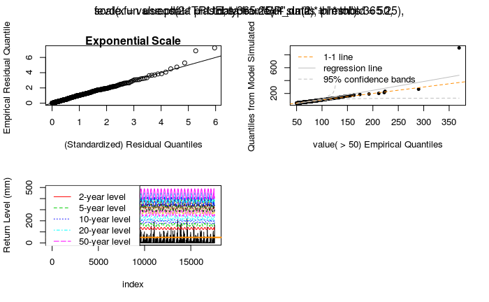

```r
plot(fit.pot2)
```

Let’s get return levels for 10, 20 and 50 year period.

```r
rlevels <- as.data.frame(unclass(return.level(fit.pot2, c(10, 20, 50))))
rlevels["tobs"] = df_data["tobs"]
rlevels["year"] = df_data["year"]

print(as.matrix(rlevels), quote = FALSE, max = 100)
```

```
      10-year level 20-year level 50-year level tobs year
1          198.0599      230.0050      276.8221    1 1969
2          197.7679      229.6499      276.3747    2 1969
3          197.4743      229.2930      275.9250    3 1969
4          197.1794      228.9345      275.4732    4 1969
5          196.8832      228.5744      275.0194    5 1969
6          196.5858      228.2128      274.5638    6 1969
7          196.2873      227.8499      274.1064    7 1969
8          195.9878      227.4857      273.6476    8 1969
9          195.6874      227.1205      273.1874    9 1969
10         195.3861      226.7543      272.7259   10 1969
11         195.0842      226.3872      272.2634   11 1969
12         194.7817      226.0194      271.7999   12 1969
13         194.4786      225.6510      271.3356   13 1969
14         194.1751      225.2820      270.8707   14 1969
15         193.8713      224.9126      270.4053   15 1969
16         193.5673      224.5430      269.9395   16 1969
17         193.2631      224.1732      269.4735   17 1969
18         192.9589      223.8033      269.0075   18 1969
19         192.6547      223.4335      268.5415   19 1969
20         192.3507      223.0639      268.0757   20 1969
 [ reached getOption("max.print") -- omitted 17557 rows ]
```

So this has `17577` rows (equivalent to number of observations).  
Let’s make it into a *tidy-form* data

```r
library(reshape2)
rlevels.melt <- melt(rlevels, id.vars = c("tobs", "year"))
print(as.matrix(rlevels.melt), quote = FALSE, max = 100)
```

```
         tobs year variable      value
    [1,]   1  1969 10-year level 198.0599
    [2,]   2  1969 10-year level 197.7679
    [3,]   3  1969 10-year level 197.4743
    [4,]   4  1969 10-year level 197.1794
    [5,]   5  1969 10-year level 196.8832
    [6,]   6  1969 10-year level 196.5858
    [7,]   7  1969 10-year level 196.2873
    [8,]   8  1969 10-year level 195.9878
    [9,]   9  1969 10-year level 195.6874
   [10,]  10  1969 10-year level 195.3861
   [11,]  11  1969 10-year level 195.0842
   [12,]  12  1969 10-year level 194.7817
   [13,]  13  1969 10-year level 194.4786
   [14,]  14  1969 10-year level 194.1751
   [15,]  15  1969 10-year level 193.8713
   [16,]  16  1969 10-year level 193.5673
   [17,]  17  1969 10-year level 193.2631
   [18,]  18  1969 10-year level 192.9589
   [19,]  19  1969 10-year level 192.6547
   [20,]  20  1969 10-year level 192.3507
   [21,]  21  1969 10-year level 192.0469
   [22,]  22  1969 10-year level 191.7434
   [23,]  23  1969 10-year level 191.4403
   [24,]  24  1969 10-year level 191.1377
   [25,]  25  1969 10-year level 190.8358
 [ reached getOption("max.print") -- omitted 52706 rows ]
```

Now let’s plot the return levels for any year, for each day of the year.  
**NOTE**: The following plot will be the same for every year. This is because our non stationarity assumption for the scale parameter is considering seasonality, and not a yearly trend in precipitation.

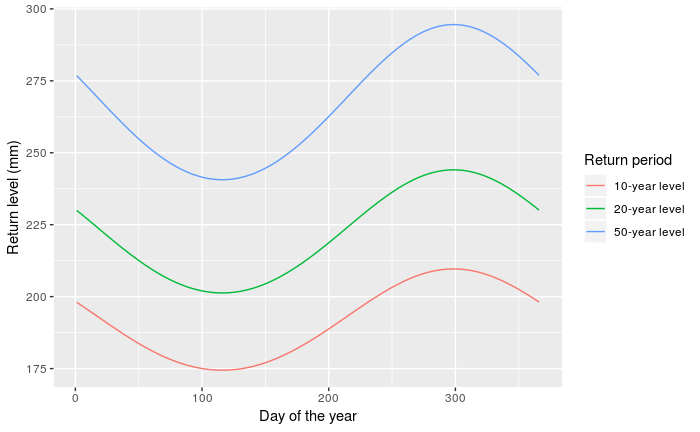

```r
library(ggplot2)
ggplot(subset(rlevels.melt, year == 2000), aes(tobs, value)) +
geom_line(aes(colour = variable)) +
xlab("Day of the year") +
ylab("Return level (mm)") +
labs(colour="Return period")
```

### Likelihood ratio test

In the same way we performed likelihood ratio test with the *more complex* Fretchet ($\mu, \sigma, \xi$) v/s the Null hypotheses i.e. the *less complex* Gumbel ($\mu, \sigma$). Here we have,  
$H_{o}$ : The scale parameter is stationary i.e. no seasonality  
$H_{a}$ : The scale parameter is non-stationary i.e. taking into account seasonality.

```r
l <- lr.test(fit.pot1, fit.pot2)
pval <- l$p.value
l
```

```
    Likelihood-ratio Test

data:  rf.p2value
Likelihood-ratio = 1.7977, chi-square critical value = 5.9915, alpha = 0.0500, Degrees of Freedom
= 2.0000, p-value = 0.407
alternative hypothesis: greater
```

We get a **p-value =** `0.407`. This means there is **NOT** sufficient evidence to reject the null hypotheses in favour of the alternate. In other words, we will use the distribution without seasonally varying scale parameter to model our data.

We can derive confidence intervals for the parameters using normal approx.

```r
ci(fit.pot2, type="parameter")
```

```
fevd(x = value, data = as.data.frame(df_data), threshold = 50,
    scale.fun = ~cos(2 * pi * tobs/365.25) + sin(2 * pi * tobs/365.25),
    use.phi = TRUE, type = "GP", units = "mm")

[1] "Normal Approx."

      95% lower CI    Estimate 95% upper CI
phi0    2.90357156  3.17533224    3.4470929
phi1   -0.23071357  0.05120804    0.3331297
phi2   -0.35387504 -0.11349674    0.1268816
shape   0.02039817  0.12786554    0.2353329
```

However, more appropriate way of finding the confidence intervals would be to look at the trace plot and find (by hit and trial) the appropriate ranges to look for when using the profile likelihood method.

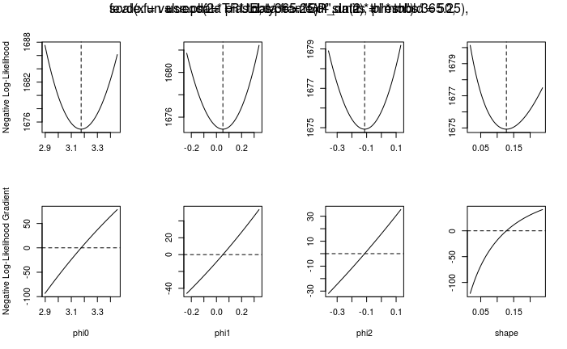

```r
suppressWarnings(plot(fit.pot2, "trace"))
```

Now using the profile-likelihood method

```r
ci(fit.pot2, type="parameter", which.par = 4, method="proflik", xrange = c(-0.3, 0.5))
```

```
fevd(x = value, data = as.data.frame(df_data), threshold = 50,
    scale.fun = ~cos(2 * pi * tobs/365.25) + sin(2 * pi * tobs/365.25),
    use.phi = TRUE, type = "GP", units = "mm")

[1] "Profile Likelihood"

[1] "shape: 0.128"

[1] "95% Confidence Interval: (0.0368, 0.2474)"
```